# Data Analysis Replication Assignment

Erin Keenan Early

March 31, 2019

## Description

Branched glycerol dialkyl glycerol tetraethers (brGDGTs) are environmental proxies recoverable from soils and sediments that allow for climatic recontruction of paleoenvironments. The paper I have selected (Loomis et al. 2012) looks at different calibration curves for calibrating brGDGT data to mean annual air temperature (MAAT). The different calibration curves put forward and tested in this study are based on different linear regressions related to brGDGT types: methylation (MBT) index, cyclization (CBT) index, relative abundance of non-cyclized brGDGTs (MbrGDGTs), and a best subsets regression (BSR) of the nine most common brGDGTs.

Loomis et al. used a dataset collected by a previous set of researchers, and added to it to create a total dataset of 111 East African lakes. The goal of this study was to determine the best calibration curve to predict MAAT for lacustrian sediments in when looking at East African lake locations. They do several linear models to demonstrate the different calibrations.

For this assignment I will be replicating the following:

1. Figure 4, which shows a correlation of MAAT to SW_ph (Mean Annual Air Temperature to Surface Water pH), including correlation coefficients.
2. Table 1, which shows a series of correlations between brGDGT fractional abundances (i.e., I, Ib, Ic etc.) and the environmental fatcors MAAT, SW_pH, and Depth.
3. The stepwise forward selection (SFS) calibration that is a novel calibration to this paper.

## Setting up my data for replication

I downloaded my dataset from the supplementary information appendix to my selected paper and combined pieces of three tables that contained the information I would be needing for this data replication assignment. I saved this combined datasheet on my computer as a .csv file. The authors of my paper state that they did not use outliers (defined as values that were three or more standard deviations away from the mean of any given dataset) for their calibrations. The values that were considered to be outliers were marked in the supplementary info, and I changed those values to “NA” to prevent their being incorporated into my calibrations.

Additionally, portions of the data referenced in the paper are missing from the supplememtary info dataset (Loomis-collected data for Depth, MAAT, SW_T, BW_T, SW_pH and BWpH). As a result I had to add the missing data to my dataset from spreadsheets compiled by my supervisor. I beieve the added data obtained from my supervisor is accurate, but cannot be certain it is the exact data that was used by the authors as it was omitted from the supplementary info.

I uploaded the my compiled .csv file using the below code:

```r
d<- "C:/Users/keena/Documents/R/Projects/Loomis2012_suppinf_Data-rep-anal.csv"
Loomis<- read.table(d, header=TRUE, sep=",", stringsAsFactors = FALSE)
head(Loomis)
```

```
##      Lake   III  IIIb  IIIc    II   IIb   IIc     I    Ib    Ic  MBT  CBT
## 1  Albert 0.085 0.002 0.000 0.464 0.047 0.004 0.332 0.054 0.012 0.40 0.90
## 2   Alice 0.197 0.005 0.000 0.530 0.057 0.007 0.180 0.018 0.005 0.20 0.98
## 3 Bandasa 0.086 0.002 0.001 0.451 0.033 0.007 0.362 0.047 0.013 0.42 1.01
## 4 Batodaa 0.339 0.002 0.001 0.449 0.014 0.003 0.186 0.006 0.001 0.19 1.50
## 5  Bigata 0.310 0.002 0.001 0.451 0.012 0.006 0.214 0.004 0.001 0.22 1.62
## 6 Bugwagi 0.031 0.005 0.001 0.310 0.127 0.012 0.343 0.150 0.021 0.51 0.37
##   MBT.CBT.MAAT MAAT SW.T BW.T SW.pH BW.pH Depth MbrGDGTs.MAAT SFS.MAAT
## 1           NA 26.8 27.9 27.9   9.0   9.0  58.0            NA       NA
## 2          6.8  9.6 12.6 13.6   7.4   8.4  26.5           8.0      7.9
## 3         16.5 12.8 14.8 14.8   8.5   8.5   0.3          16.2     15.2
## 4          3.7  4.2  7.5  6.1   5.2   5.0  16.0           3.8      4.9
## 5          4.3  4.2  8.3  5.3   5.2   6.0  17.5           5.1      4.5
## 6         23.9 24.0 26.5 24.7   8.8   7.2  85.0          24.0     25.7
```

```r
names(Loomis)
```

```
##  [1] "Lake"          "III"           "IIIb"          "IIIc"
##  [5] "II"            "IIb"           "IIc"           "I"
##  [9] "Ib"            "Ic"            "MBT"           "CBT"
## [13] "MBT.CBT.MAAT"  "MAAT"          "SW.T"          "BW.T"
## [17] "SW.pH"         "BW.pH"         "Depth"         "MbrGDGTs.MAAT"
## [21] "SFS.MAAT"
```

I created a series of functions I could use to begin data replication. Though the dataset included their calculated MBT and CBT indexes, I decided to recalculate them myself as part of my replication.

```r
#function replicating Weijers equation for MBT index
MBT<- function(data) {
  (data$I+data$Ib+data$Ic)/(data$I+data$Ib+data$Ic+data$II+data$IIb+data$IIc+data$III+data$IIIb+data$IIIc)
}

#function replicating Weijers equation for CBT index
CBT<- function(data) {
  -log10((data$Ib+data$IIb)/(data$I+data$II))
}
```

```r
names(Loomis)
```

```
##  [1] "Lake"          "III"           "IIIb"          "IIIc"
##  [5] "II"            "IIb"           "IIc"           "I"
##  [9] "Ib"            "Ic"            "MBT"           "CBT"
## [13] "MBT.CBT.MAAT"  "MAAT"          "SW.T"          "BW.T"
## [17] "SW.pH"         "BW.pH"         "Depth"         "MbrGDGTs.MAAT"
## [21] "SFS.MAAT"
```

I then created a series of separate data frames containg the data that I would need to run my reanalysis

```r
Lakes<- data.frame(Loomis$Lake) #List of Lakes
MAAT<- data.frame((Loomis$MAAT)) #mean annual air temperature as provided by dataset
SWph<- data.frame(Loomis$SW.pH) #surface water temperature as provided by dataset
methyl<-data.frame(MBT(Loomis)) # my recalculation of MBT index from Wiejers equation
cyc<- data.frame(CBT(Loomis)) # my recalculation of CBT index from Wiejers equation
Mbr<- data.frame(Loomis$MbrGDGTs.MAAT) # Major branched GDGTs calibration (equation not provided in paper) from dataset
MBTCBT<- data.frame(Loomis$MBT.CBT.MAAT) # ratio of MBT:CBT from dataset
output<- cbind(Lakes,methyl,cyc,Mbr,MBTCBT,MAAT,SWph) #creation of my new dataset for regressions and analyses

I<- data.frame(Loomis$I)
Ib<- data.frame(Loomis$Ib)
Ic<- data.frame(Loomis$Ic)
II<- data.frame(Loomis$II)
IIb<- data.frame(Loomis$IIb)
IIc<- data.frame(Loomis$IIc)
III<- data.frame(Loomis$III)
IIIb<- data.frame(Loomis$IIIb)
IIIc<- data.frame(Loomis$IIIc)
frac.abund<- cbind(MAAT, I, Ib, Ic, II, IIb, IIc, III, IIIb, IIIc) #creation of dataset containing only fractional abundances
```

```r
names(output)
```

```
## [1] "Loomis.Lake"          "MBT.Loomis."          "CBT.Loomis."
## [4] "Loomis.MbrGDGTs.MAAT" "Loomis.MBT.CBT.MAAT"  "X.Loomis.MAAT."
## [7] "Loomis.SW.pH"
```

Following these steps, I am now able to proceed with my data reanalysis using my new “output” data frame.

## Replication of Figure 4

Figure 4 from my paper shows a scatterplot of Surface Water pH as a function of Observed MAAT in degrees Celsius. Within this scatterplot are two linear regressions. The first is a regression fro data covering all of the lakes in the study, and the second is a regresion covering only the lakes with MAAT less than 16 degrees Celsius.

I first ran a linear regression for All Lakes

```r
# linear regression of surface water pH as a function of MAAT for all lakes
fig4lm<- lm(Loomis.SW.pH~X.Loomis.MAAT., data=output)
summary(fig4lm)
```

```
##
## Call:
## lm(formula = Loomis.SW.pH ~ X.Loomis.MAAT., data = output)
##
## Residuals:
##      Min       1Q   Median       3Q      Max
## -2.87152 -0.45748  0.08388  0.56369  2.22848
##
## Coefficients:
##                Estimate Std. Error t value Pr(>|t|)
## (Intercept)     6.07322    0.17521   34.66   <2e-16 ***
## X.Loomis.MAAT.  0.11080    0.01015   10.92   <2e-16 ***
## ---
## Signif. codes:  0 '***' 0.001 '**' 0.01 '*' 0.05 '.' 0.1 ' ' 1
##
## Residual standard error: 0.8872 on 109 degrees of freedom
## Multiple R-squared:  0.5223, Adjusted R-squared:  0.5179
## F-statistic: 119.2 on 1 and 109 DF,  p-value: < 2.2e-16
```

I next ran a linear regression for Lakes less than 16 degrees Celsius

```r
# linear regression of surface water pH as a function of MAAT for lakes<16 degrees C
library(dplyr)
```

```r
lake16<- filter(Loomis, MAAT < 16)
fig416<- lm(SW.pH~MAAT, data=lake16)
summary(fig416)
```

```
##
## Call:
## lm(formula = SW.pH ~ MAAT, data = lake16)
##
## Residuals:
##     Min      1Q  Median      3Q     Max
## -2.9221 -0.6769  0.2046  0.8779  2.1779
##
## Coefficients:
##             Estimate Std. Error t value Pr(>|t|)
## (Intercept)  6.44211    0.30628  21.034   <2e-16 ***
## MAAT         0.05185    0.03663   1.416    0.163
## ---
## Signif. codes:  0 '***' 0.001 '**' 0.01 '*' 0.05 '.' 0.1 ' ' 1
##
## Residual standard error: 1.117 on 52 degrees of freedom
## Multiple R-squared:  0.03711,    Adjusted R-squared:  0.01859
## F-statistic: 2.004 on 1 and 52 DF,  p-value: 0.1628
```

Finally I calculated the correlation coefficients for both All Lakes and Lakes<16“”

```r
corcoAll<- cor(output$Loomis.SW.pH, output$X.Loomis.MAAT., method="pearson")
corcoAll
```

```
## [1] 0.7226992
```

```r
corco16<- cor(lake16$SW.pH, lake16$MAAT, method="pearson")
corco16
```

```
## [1] 0.1926442
```

I then created Figure 4 by plotting both of the regressions:

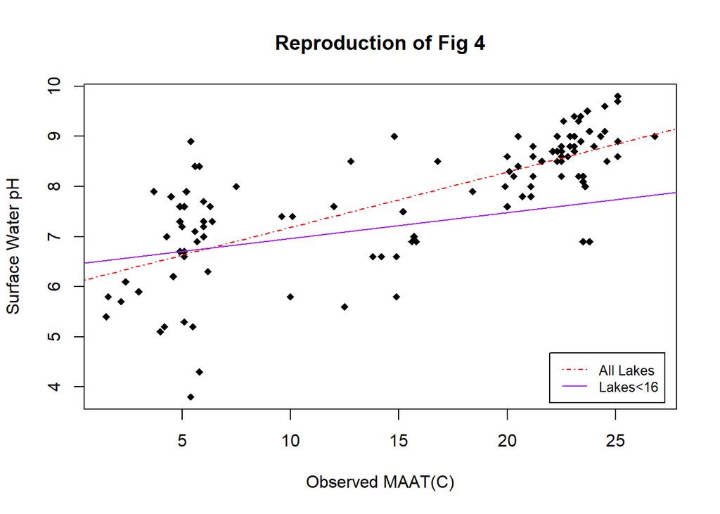

```r
#Reproduction of Figure 4 from Loomis et al. 2012
fig4<- plot(data=output, Loomis.SW.pH~X.Loomis.MAAT., xlab= "Observed MAAT(C)", ylab="Surface Water pH", main="Reproduction of Fig 4", pch=18)
fig4<- fig4+abline(fig4lm, col="red", lty = 4)
fig4<- fig4+abline(fig416, col="purple", lty = 1)
legend("bottomright", inset=.02, lty = c(4,1),
   c("All Lakes","Lakes<16"), col= c("red", "purple"), cex=0.8)
```

Visually my table aligns with the one in Loomis et al., with data points appearing to match and with the slopes of the respective regression lines agreeing with the figure in the paper (the paper does not report the actual value of the slope and intercept of the regression lines).

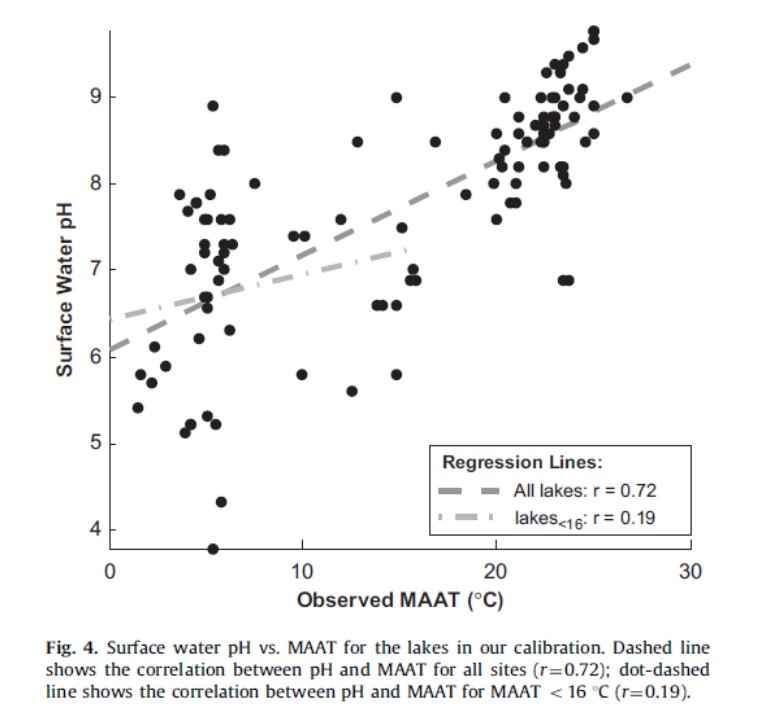

The r-value of the Lakes<16 reported in the paper is r=0.19, and my Lakes<16 r-value is r=0.1926442. The r-value of for All Lakes in the paper is r=0.72, while my replication gives a value of r=0.7226992. These both match the correlation coefficients stated in the paper.

## Replication of Table 1

Table 1 in my paper shows the correlation coefficients and p-values for the fractional abundances of each type of brGDGT (i.e., I, II, IIc etc.) and MAAT, SW_pH, and Depth (of the lake). Part (a) shows these values for All Lakes and part (b) shows these values for Lakes<16.

```r
names(Loomis)
```

```
##  [1] "Lake"          "III"           "IIIb"          "IIIc"
##  [5] "II"            "IIb"           "IIc"           "I"
##  [9] "Ib"            "Ic"            "MBT"           "CBT"
## [13] "MBT.CBT.MAAT"  "MAAT"          "SW.T"          "BW.T"
## [17] "SW.pH"         "BW.pH"         "Depth"         "MbrGDGTs.MAAT"
## [21] "SFS.MAAT"
```

For clarity, I split Table 1a and Table 1b into two separate analyses. I replicated Table 1a first:

```r
I<- cor(Loomis$I,Loomis$MAAT, method = "pearson")
Ib<- cor(Loomis$Ib,Loomis$MAAT, method = "pearson")
Ic<- cor(Loomis$Ic,Loomis$MAAT, method = "pearson")
II<- cor(Loomis$II,Loomis$MAAT, method = "pearson")
IIb<- cor(Loomis$IIb,Loomis$MAAT, method = "pearson")
IIc<- cor(Loomis$IIc,Loomis$MAAT, method = "pearson")
III<- cor(Loomis$III,Loomis$MAAT, method = "pearson")
IIIb<- cor(Loomis$IIIb,Loomis$MAAT, method = "pearson")
IIIc<- cor(Loomis$IIIc,Loomis$MAAT, method = "pearson")
corMAAT<-cbind(I, Ib, Ic, II, IIb, IIc, III, IIIb, IIIc)

I<- lm(I~MAAT, data= Loomis)
I<- summary(I)$coefficients[2,4]
Ib<- lm(Ib~MAAT, data= Loomis)
Ib<- summary(Ib)$coefficients[2,4]
Ic<- lm(Ic~MAAT, data= Loomis)
Ic<- summary(Ic)$coefficients[2,4]
II<- lm(II~MAAT, data= Loomis)
II<- summary(II)$coefficients[2,4]
IIb<- lm(IIb~MAAT, data= Loomis)
IIb<- summary(IIb)$coefficients[2,4]
IIc<- lm(IIc~MAAT, data= Loomis)
IIc<- summary(IIc)$coefficients[2,4]
III<- lm(III~MAAT, data= Loomis)
III<- summary(III)$coefficients[2,4]
IIIb<- lm(IIIb~MAAT, data= Loomis)
IIIb<- summary(IIIb)$coefficients[2,4]
IIIc<- lm(IIIc~MAAT, data= Loomis)
IIIc<- summary(IIIc)$coefficients[2,4]
pMAAT<- cbind(I, Ib, Ic, II, IIb, IIc, III, IIIb, IIIc)

I<- cor(Loomis$I,Loomis$SW.pH, method = "pearson")
Ib<- cor(Loomis$Ib,Loomis$SW.pH, method = "pearson")
Ic<- cor(Loomis$Ic,Loomis$SW.pH, method = "pearson")
II<- cor(Loomis$II,Loomis$SW.pH, method = "pearson")
IIb<- cor(Loomis$IIb,Loomis$SW.pH, method = "pearson")
IIc<- cor(Loomis$IIc,Loomis$SW.pH, method = "pearson")
III<- cor(Loomis$III,Loomis$SW.pH, method = "pearson")
IIIb<- cor(Loomis$IIIb,Loomis$SW.pH, method = "pearson")
IIIc<- cor(Loomis$IIIc,Loomis$SW.pH, method = "pearson")
corSWpH<-cbind(I, Ib, Ic, II, IIb, IIc, III, IIIb, IIIc)

I<- lm(I~SW.pH, data= Loomis)
I<- summary(I)$coefficients[2,4]
Ib<- lm(Ib~SW.pH, data= Loomis)
Ib<- summary(Ib)$coefficients[2,4]
Ic<- lm(Ic~SW.pH, data= Loomis)
Ic<- summary(Ic)$coefficients[2,4]
II<- lm(II~SW.pH, data= Loomis)
II<- summary(II)$coefficients[2,4]
IIb<- lm(IIb~SW.pH, data= Loomis)
IIb<- summary(IIb)$coefficients[2,4]
IIc<- lm(IIc~SW.pH, data= Loomis)
IIc<- summary(IIc)$coefficients[2,4]
III<- lm(III~SW.pH, data= Loomis)
III<- summary(III)$coefficients[2,4]
IIIb<- lm(IIIb~SW.pH, data= Loomis)
IIIb<- summary(IIIb)$coefficients[2,4]
IIIc<- lm(IIIc~SW.pH, data= Loomis)
IIIc<- summary(IIIc)$coefficients[2,4]
pSWpH<- cbind(I, Ib, Ic, II, IIb, IIc, III, IIIb, IIIc)

I<- cor(Loomis$I,Loomis$Depth, method = "pearson")
Ib<- cor(Loomis$Ib,Loomis$Depth, method = "pearson")
Ic<- cor(Loomis$Ic,Loomis$Depth, method = "pearson")
II<- cor(Loomis$II,Loomis$Depth, method = "pearson")
IIb<- cor(Loomis$IIb,Loomis$Depth, method = "pearson")
IIc<- cor(Loomis$IIc,Loomis$Depth, method = "pearson")
III<- cor(Loomis$III,Loomis$Depth, method = "pearson")
IIIb<- cor(Loomis$IIIb,Loomis$Depth, method = "pearson")
IIIc<- cor(Loomis$IIIc,Loomis$Depth, method = "pearson")
corDepth<-cbind(I, Ib, Ic, II, IIb, IIc, III, IIIb, IIIc)

I<- lm(I~Depth, data= Loomis)
I<- summary(I)$coefficients[2,4]
Ib<- lm(Ib~Depth, data= Loomis)
Ib<- summary(Ib)$coefficients[2,4]
Ic<- lm(Ic~Depth, data= Loomis)
Ic<- summary(Ic)$coefficients[2,4]
II<- lm(II~Depth, data= Loomis)
II<- summary(II)$coefficients[2,4]
IIb<- lm(IIb~Depth, data= Loomis)
IIb<- summary(IIb)$coefficients[2,4]
IIc<- lm(IIc~Depth, data= Loomis)
IIc<- summary(IIc)$coefficients[2,4]
III<- lm(III~Depth, data= Loomis)
III<- summary(III)$coefficients[2,4]
IIIb<- lm(IIIb~Depth, data= Loomis)
IIIb<- summary(IIIb)$coefficients[2,4]
IIIc<- lm(IIIc~Depth, data= Loomis)
IIIc<- summary(IIIc)$coefficients[2,4]
pDepth<- cbind(I, Ib, Ic, II, IIb, IIc, III, IIIb, IIIc)

Table1a<- data.frame(rbind(corMAAT, pMAAT, corSWpH, pSWpH, corDepth, pDepth))
library(data.table)
setattr(Table1a, "row.names", c("MAAT", "MAAT p-value", "SW pH", "SW pH p-value", "Depth", "Depth p-value"))
Table1a
```

```
##                          I           Ib           Ic            II
## MAAT          7.690748e-01 8.444755e-01 5.322855e-01 -5.336471e-01
## MAAT p-value  6.381993e-23 2.495691e-31 1.826667e-09  1.631661e-09
## SW pH         3.436029e-01 7.393087e-01 4.891273e-01 -4.126524e-01
## SW pH p-value 2.223446e-04 1.948239e-20 5.116416e-08  6.776575e-06
## Depth         9.481883e-02 4.349838e-01 3.575531e-01 -2.042175e-01
## Depth p-value 3.222219e-01 1.835791e-06 1.168812e-04  3.156151e-02
##                        IIb        IIc           III         IIIb
## MAAT          4.577546e-01 0.01379489 -8.907375e-01 7.095637e-02
## MAAT p-value  4.389140e-07 0.88573753  4.023065e-39 4.592741e-01
## SW pH         6.296506e-01 0.19568642 -6.301143e-01 3.940328e-01
## SW pH p-value 1.336128e-13 0.03956227  1.266556e-13 1.878743e-05
## Depth         3.538290e-01 0.23509775 -2.986680e-01 1.103831e-01
## Depth p-value 1.391784e-04 0.01299936  1.452323e-03 2.487783e-01
##                     IIIc
## MAAT          0.19767325
## MAAT p-value  0.03756144
## SW pH         0.18215276
## SW pH p-value 0.05569505
## Depth         0.22465624
## Depth p-value 0.01776440
```

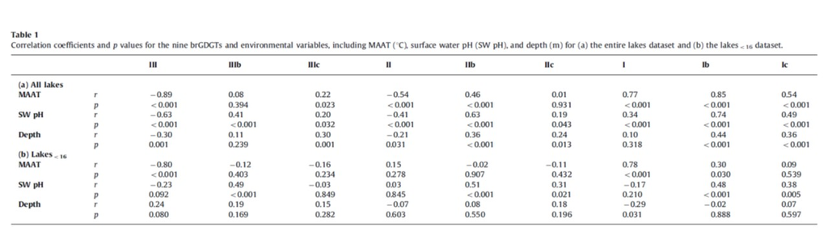

I then replicated Table 1b, which runs the same analysis as Table 1a, but using only Lakes<16:

```r
I<- cor(lake16$I,lake16$MAAT, method = "pearson")
Ib<- cor(lake16$Ib,lake16$MAAT, method = "pearson")
Ic<- cor(lake16$Ic,lake16$MAAT, method = "pearson")
II<- cor(lake16$II,lake16$MAAT, method = "pearson")
IIb<- cor(lake16$IIb,lake16$MAAT, method = "pearson")
IIc<- cor(lake16$IIc,lake16$MAAT, method = "pearson")
III<- cor(lake16$III,lake16$MAAT, method = "pearson")
IIIb<- cor(lake16$IIIb,lake16$MAAT, method = "pearson")
IIIc<- cor(lake16$IIIc,lake16$MAAT, method = "pearson")
corMAAT16<-cbind(I, Ib, Ic, II, IIb, IIc, III, IIIb, IIIc)

I<- lm(I~MAAT, data= lake16)
I<- summary(I)$coefficients[2,4]
Ib<- lm(Ib~MAAT, data= lake16)
Ib<- summary(Ib)$coefficients[2,4]
Ic<- lm(Ic~MAAT, data= lake16)
Ic<- summary(Ic)$coefficients[2,4]
II<- lm(II~MAAT, data= lake16)
II<- summary(II)$coefficients[2,4]
IIb<- lm(IIb~MAAT, data= lake16)
IIb<- summary(IIb)$coefficients[2,4]
IIc<- lm(IIc~MAAT, data= lake16)
IIc<- summary(IIc)$coefficients[2,4]
III<- lm(III~MAAT, data= lake16)
III<- summary(III)$coefficients[2,4]
IIIb<- lm(IIIb~MAAT, data= lake16)
IIIb<- summary(IIIb)$coefficients[2,4]
IIIc<- lm(IIIc~MAAT, data= lake16)
IIIc<- summary(IIIc)$coefficients[2,4]
pMAAT16<- cbind(I, Ib, Ic, II, IIb, IIc, III, IIIb, IIIc)

I<- cor(lake16$I,lake16$SW.pH, method = "pearson")
Ib<- cor(lake16$Ib,lake16$SW.pH, method = "pearson")
Ic<- cor(lake16$Ic,lake16$SW.pH, method = "pearson")
II<- cor(lake16$II,lake16$SW.pH, method = "pearson")
IIb<- cor(lake16$IIb,lake16$SW.pH, method = "pearson")
IIc<- cor(lake16$IIc,lake16$SW.pH, method = "pearson")
III<- cor(lake16$III,lake16$SW.pH, method = "pearson")
IIIb<- cor(lake16$IIIb,lake16$SW.pH, method = "pearson")
IIIc<- cor(lake16$IIIc,lake16$SW.pH, method = "pearson")
corSWpH16<-cbind(I, Ib, Ic, II, IIb, IIc, III, IIIb, IIIc)

I<- lm(I~SW.pH, data= lake16)
I<- summary(I)$coefficients[2,4]
Ib<- lm(Ib~SW.pH, data= lake16)
Ib<- summary(Ib)$coefficients[2,4]
Ic<- lm(Ic~SW.pH, data= lake16)
Ic<- summary(Ic)$coefficients[2,4]
II<- lm(II~SW.pH, data= lake16)
II<- summary(II)$coefficients[2,4]
IIb<- lm(IIb~SW.pH, data= lake16)
IIb<- summary(IIb)$coefficients[2,4]
IIc<- lm(IIc~SW.pH, data= lake16)
IIc<- summary(IIc)$coefficients[2,4]
III<- lm(III~SW.pH, data= lake16)
III<- summary(III)$coefficients[2,4]
IIIb<- lm(IIIb~SW.pH, data= lake16)
IIIb<- summary(IIIb)$coefficients[2,4]
IIIc<- lm(IIIc~SW.pH, data= lake16)
IIIc<- summary(IIIc)$coefficients[2,4]
pSWpH16<- cbind(I, Ib, Ic, II, IIb, IIc, III, IIIb, IIIc)

I<- cor(lake16$I,lake16$Depth, method = "pearson")
Ib<- cor(lake16$Ib,lake16$Depth, method = "pearson")
Ic<- cor(lake16$Ic,lake16$Depth, method = "pearson")
II<- cor(lake16$II,lake16$Depth, method = "pearson")
IIb<- cor(lake16$IIb,lake16$Depth, method = "pearson")
IIc<- cor(lake16$IIc,lake16$Depth, method = "pearson")
III<- cor(lake16$III,lake16$Depth, method = "pearson")
IIIb<- cor(lake16$IIIb,lake16$Depth, method = "pearson")
IIIc<- cor(lake16$IIIc,lake16$Depth, method = "pearson")
corDepth16<-cbind(I, Ib, Ic, II, IIb, IIc, III, IIIb, IIIc)

I<- lm(I~Depth, data= lake16)
I<- summary(I)$coefficients[2,4]
Ib<- lm(Ib~Depth, data= lake16)
Ib<- summary(Ib)$coefficients[2,4]
Ic<- lm(Ic~Depth, data= lake16)
Ic<- summary(Ic)$coefficients[2,4]
II<- lm(II~Depth, data= lake16)
II<- summary(II)$coefficients[2,4]
IIb<- lm(IIb~Depth, data= lake16)
IIb<- summary(IIb)$coefficients[2,4]
IIc<- lm(IIc~Depth, data= lake16)
IIc<- summary(IIc)$coefficients[2,4]
III<- lm(III~Depth, data= lake16)
III<- summary(III)$coefficients[2,4]
IIIb<- lm(IIIb~Depth, data= lake16)
IIIb<- summary(IIIb)$coefficients[2,4]
IIIc<- lm(IIIc~Depth, data= lake16)
IIIc<- summary(IIIc)$coefficients[2,4]
pDepth16<- cbind(I, Ib, Ic, II, IIb, IIc, III, IIIb, IIIc)

Table1b<- data.frame(rbind(corMAAT16, pMAAT16, corSWpH16, pSWpH16, corDepth16, pDepth16))
library(data.table)
setattr(Table1b, "row.names", c("MAAT", "MAAT p-value", "SW pH", "SW pH p-value", "Depth", "Depth p-value"))
Table1b
```

```
##                           I            Ib          Ic          II
## MAAT           7.789366e-01  0.2899481090 0.079479885  0.17557412
## MAAT p-value   4.044709e-12  0.0334417738 0.567800186  0.20411917
## SW pH         -1.736197e-01  0.4858144025 0.373893501  0.02716957
## SW pH p-value  2.092803e-01  0.0001961219 0.005351973  0.84537808
## Depth         -2.933320e-01 -0.0245794753 0.071956619 -0.06693799
## Depth p-value  3.134191e-02  0.8599626038 0.605107666  0.63057191
##                         IIb         IIc           III          IIIb
## MAAT          -2.718673e-02 -0.11591743 -8.060703e-01 -0.1212328908
## MAAT p-value   8.452816e-01  0.40388482  1.927935e-13  0.3825225270
## SW pH          5.125952e-01  0.31378804 -2.316661e-01  0.4903448488
## SW pH p-value  7.408585e-05  0.02085479  9.187798e-02  0.0001672782
## Depth          7.550812e-02  0.17471293  2.429468e-01  0.1697469757
## Depth p-value  5.873629e-01  0.20638217  7.670392e-02  0.2197767921
##                      IIIc
## MAAT          -0.13683725
## MAAT p-value   0.32380599
## SW pH         -0.04365959
## SW pH p-value  0.75392087
## Depth          0.17228258
## Depth p-value  0.21286378
```

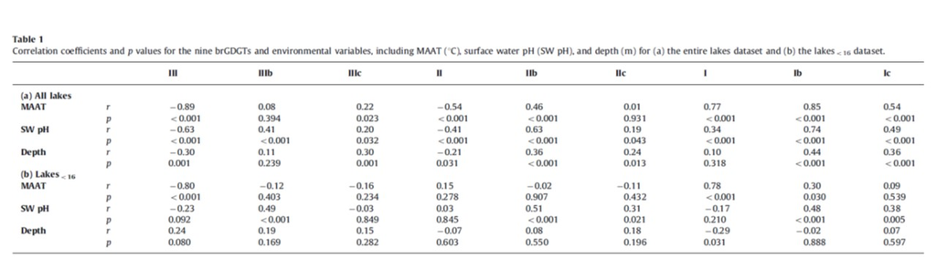

## Reproducing Stepwise Forward Selection (SFS) Calibration

The authors are seeking to improve predictions of MAAT based on fractional abundances of brGDGTs from East African lakes. To this end they introduce a new calibration calculated using stepwise forward selection (SFS), a type of stepwise regression. To do this they take their highest correlation for all lakes (III and MAAT = 0.89) and use it as their starting value. They then add other fractional abundancies to the linear regression model to see if it improves the corelation coefficient. If it does it stays, if it doesn’t it is removed.

I will replicate the calculation of this SFS calibration below.

I’m starting by loading some necessary packages and selecting the same fractional abundance (III) as the authors of my paper did, because it is has the highest correlation to MAAT (-0.8907375 in my calculations). For this I will use my frac.abund dataset.

```r
names(frac.abund)
```

```
##  [1] "X.Loomis.MAAT." "Loomis.I"       "Loomis.Ib"      "Loomis.Ic"
##  [5] "Loomis.II"      "Loomis.IIb"     "Loomis.IIc"     "Loomis.III"
##  [9] "Loomis.IIIb"    "Loomis.IIIc"
```

```r
library(tidyverse)
library(caret)
library(leaps)
library(MASS)
#Set up my stepwise model to identify the best model with the lowest RMSE
train.control<- trainControl(method = "cv", number=50)
step.model<- train(X.Loomis.MAAT.~., data= frac.abund, method = "leapForward", tuneGrid= data.frame(nvmax= 1:9), trControl = train.control)
step.model$results
```

```
##   nvmax     RMSE  Rsquared      MAE   RMSESD RsquaredSD    MAESD
## 1     1 3.471965 0.9826469 3.051361 1.764466 0.06797563 1.538673
## 2     2 2.787910 0.9773579 2.424947 1.679341 0.13185227 1.457853
## 3     3 2.328560 0.9864263 2.024994 1.584552 0.06708038 1.344397
## 4     4 2.281468 0.9882287 1.979535 1.506260 0.06262002 1.282440
## 5     5 2.346439 0.9879320 2.038894 1.580745 0.06431005 1.325282
## 6     6 2.380733 0.9883794 2.073819 1.602985 0.06198747 1.363928
## 7     7 2.403968 0.9880307 2.089933 1.631078 0.06514131 1.380180
## 8     8 2.401298 0.9882286 2.090771 1.625198 0.06375653 1.383457
## 9     9 2.420067 0.9878395 2.108504 1.628932 0.06589793 1.390720
```

I can visually pick out the best model (the one with the lowest RMSE), but the following code highlights it for me:

```r
step.model$bestTune
```

```
##   nvmax
## 4     4
```

This shows that the fourth model is the best model. To identify the variables that produced this model I input the following code:

```r
summary(step.model$finalModel)
```

```
## Subset selection object
## 9 Variables  (and intercept)
##             Forced in Forced out
## Loomis.I        FALSE      FALSE
## Loomis.Ib       FALSE      FALSE
## Loomis.Ic       FALSE      FALSE
## Loomis.II       FALSE      FALSE
## Loomis.IIb      FALSE      FALSE
## Loomis.IIc      FALSE      FALSE
## Loomis.III      FALSE      FALSE
## Loomis.IIIb     FALSE      FALSE
## Loomis.IIIc     FALSE      FALSE
## 1 subsets of each size up to 4
## Selection Algorithm: forward
##          Loomis.I Loomis.Ib Loomis.Ic Loomis.II Loomis.IIb Loomis.IIc
## 1  ( 1 ) " "      " "       " "       " "       " "        " "
## 2  ( 1 ) " "      "*"       " "       " "       " "        " "
## 3  ( 1 ) " "      "*"       " "       " "       " "        "*"
## 4  ( 1 ) " "      "*"       "*"       " "       " "        "*"
##          Loomis.III Loomis.IIIb Loomis.IIIc
## 1  ( 1 ) "*"        " "         " "
## 2  ( 1 ) "*"        " "         " "
## 3  ( 1 ) "*"        " "         " "
## 4  ( 1 ) "*"        " "         " "
```

The asterisks indicate which variables are included in my best fit model: Ib, Ic, IIc, III. Thus, the best regression is MAAT~Ib+Ic+IIc+III.

To get the coefficients that correspond to this function I input the following code:

```r
SFS<- lm(X.Loomis.MAAT.~Loomis.III+Loomis.Ib+Loomis.Ic+Loomis.IIc, data= frac.abund)
SFS
```

```
##
## Call:
## lm(formula = X.Loomis.MAAT. ~ Loomis.III + Loomis.Ib + Loomis.Ic +
##     Loomis.IIc, data = frac.abund)
##
## Coefficients:
## (Intercept)   Loomis.III    Loomis.Ib    Loomis.Ic   Loomis.IIc
##       16.89       -32.87        78.25       178.35      -470.29
```

This gives a final equation of:

MAAT = 16.89 - 32.87(III) + 178.35(Ic) - 470.29(IIc) + 78.25(Ib)

This does not match the calibration given in the paper, which is:

MAAT = 22.77 - 33.58(III) - 12.88(II) - 418.53(IIc) + 86.43(Ib)

The equations are similar, but the differ in that mine includes Ic as a part of the calibration in place of II in theirs.

As an experiment I ran the a model using the same variables as the paper, and though the numbers are similar, they still are not identical to those given by the authors:

```r
SFS<- lm(X.Loomis.MAAT.~Loomis.III+Loomis.II+Loomis.IIc+Loomis.Ib, data= frac.abund)
SFS
```

```
##
## Call:
## lm(formula = X.Loomis.MAAT. ~ Loomis.III + Loomis.II + Loomis.IIc +
##     Loomis.Ib, data = frac.abund)
##
## Coefficients:
## (Intercept)   Loomis.III    Loomis.II   Loomis.IIc    Loomis.Ib
##      21.994      -36.082       -9.788     -322.996       78.894
```

I checked to see if this disparity was due to a failure to properly remove outliers from my dataset, as the paper had stated calibrations did not include outliers. I edited my original .csv file to remove all such values and imported it as a new dataset:

```r
d<- "C:/Users/keena/Documents/R/Projects/Loomis2012_suppinf_Data-rep-anal_NA.csv"
outliers<- read.table(d, header=TRUE, sep=",", stringsAsFactors = FALSE)
head(outliers)
```

```
##      Lake   III  IIIb  IIIc    II   IIb   IIc     I    Ib    Ic MAAT
## 1   Alice 0.197 0.005 0.000 0.530 0.057 0.007 0.180 0.018 0.005  9.6
## 2 Bandasa 0.086 0.002 0.001 0.451 0.033 0.007 0.362 0.047 0.013 12.8
## 3 Batodaa 0.339 0.002 0.001 0.449 0.014 0.003 0.186 0.006 0.001  4.2
## 4  Bigata 0.310 0.002 0.001 0.451 0.012 0.006 0.214 0.004 0.001  4.2
## 5 Bugwagi 0.031 0.005 0.001 0.310 0.127 0.012 0.343 0.150 0.021 24.0
## 6  Bujuku 0.411 0.004 0.001 0.383 0.029 0.006 0.150 0.013 0.003  4.6
```

I then ran the same SFS process using this new dataset:

```r
#Set up my stepwise model to identify the best model with the lowest RMSE
train.control2<- trainControl(method = "cv", number=10)
step.model2<- train(MAAT~., data= outliers, method = "leapForward", tuneGrid= data.frame(nvmax= 1:9), trControl = train.control)
```

[output not shown]

[output not shown]

[output not shown]

[output not shown]

[output not shown]

[output not shown]

[output not shown]

[output not shown]

[output not shown]

[output not shown]

[output not shown]

[output not shown]

[output not shown]

[output not shown]

[output not shown]

[output not shown]

[output not shown]

[output not shown]

[output not shown]

[output not shown]

[output not shown]

[output not shown]

[output not shown]

[output not shown]

[output not shown]

[output not shown]

[output not shown]

[output not shown]

[output not shown]

[output not shown]

[output not shown]

[output not shown]

[output not shown]

[output not shown]

[output not shown]

[output not shown]

[output not shown]

[output not shown]

[output not shown]

[output not shown]

[output not shown]

[output not shown]

[output not shown]

[output not shown]

[output not shown]

[output not shown]

[output not shown]

[output not shown]

[output not shown]

[output not shown]

```r
step.model2$results
```

```
##   nvmax     RMSE  Rsquared      MAE    RMSESD RsquaredSD     MAESD
## 1     1 3.127582 0.9597328 2.863683 1.7483432  0.1689504 1.6120697
## 2     2 2.543741 0.9700503 2.222662 1.4831624  0.1450213 1.3081058
## 3     3 2.020510 0.9700991 1.755689 1.1396396  0.1410535 0.9363743
## 4     4 1.848922 0.9675140 1.640411 0.7574280  0.1517564 0.6863731
## 5     5 1.893962 0.9675764 1.678813 0.8286932  0.1514944 0.7566417
## 6     6 1.904382 0.9675767 1.689096 0.8509418  0.1514856 0.7861890
## 7     7 1.897334 0.9681578 1.685997 0.8407891  0.1494710 0.7812062
## 8     8 1.925836 0.9681544 1.712288 0.8759859  0.1493293 0.8091005
## 9     9 1.924091 0.9677110 1.711481 0.9069413  0.1484592 0.8300038
```

```r
step.model2$bestTune
```

```
##   nvmax
## 4     4
```

```r
summary(step.model$finalModel)
```

```
## Subset selection object
## 9 Variables  (and intercept)
##             Forced in Forced out
## Loomis.I        FALSE      FALSE
## Loomis.Ib       FALSE      FALSE
## Loomis.Ic       FALSE      FALSE
## Loomis.II       FALSE      FALSE
## Loomis.IIb      FALSE      FALSE
## Loomis.IIc      FALSE      FALSE
## Loomis.III      FALSE      FALSE
## Loomis.IIIb     FALSE      FALSE
## Loomis.IIIc     FALSE      FALSE
## 1 subsets of each size up to 4
## Selection Algorithm: forward
##          Loomis.I Loomis.Ib Loomis.Ic Loomis.II Loomis.IIb Loomis.IIc
## 1  ( 1 ) " "      " "       " "       " "       " "        " "
## 2  ( 1 ) " "      "*"       " "       " "       " "        " "
## 3  ( 1 ) " "      "*"       " "       " "       " "        "*"
## 4  ( 1 ) " "      "*"       "*"       " "       " "        "*"
##          Loomis.III Loomis.IIIb Loomis.IIIc
## 1  ( 1 ) "*"        " "         " "
## 2  ( 1 ) "*"        " "         " "
## 3  ( 1 ) "*"        " "         " "
## 4  ( 1 ) "*"        " "         " "
```

The coefficients for this are:

```r
SFS2<- lm(MAAT~III+Ib+Ic+IIc, data= outliers)
SFS2
```

```
##
## Call:
## lm(formula = MAAT ~ III + Ib + Ic + IIc, data = outliers)
##
## Coefficients:
## (Intercept)          III           Ib           Ic          IIc
##       16.51       -31.59        92.57        99.35      -475.72
```

With the equation of:

MAAT = 16.51 - 31.59(III) + 99.35(Ic) 1 475.72(IIc) + 92.57(Ib)

as opposed to

MAAT = 22.77 - 33.58(III) - 12.88(II) - 418.53(IIc) + 86.43(Ib)

from the paper and

MAAT = 16.89 - 32.87(III) + 178.35(Ic) - 470.29(IIc) + 78.25(Ib)

from my first SFS equation.

Checking the variables selected in the paper using the new “outliers” database gives the following coefficients:

```r
SFS2<- lm(MAAT~III+II+IIc+Ib, data= outliers)
SFS2
```

```
##
## Call:
## lm(formula = MAAT ~ III + II + IIc + Ib, data = outliers)
##
## Coefficients:
## (Intercept)          III           II          IIc           Ib
##       24.33       -35.30       -15.37      -386.49        77.77
```

Which also don’t align with the coefficients given in the paper.

## Concluding thoughts

I am pleased that I was able to replicate Figure 4, and I was fairly successful in replicating Table 1a and Table 1b. However, slight variations in my results in Table 1 and the results the authors provide in their Table 1 seem to foreshadow the misalignments between my replication on the SFS calibration model and the SFS calibration model provided in the paper. There appears to be some variation in the fractional abundancies in my dataset and the fractional abundancies they used in their data analyses. However, the fractional abundancies in my dataset are all taken directly from the supplemental information provided in the paper. As such I am not sure where the disconnect lies. While it may be a result of rounding (I made no effort to round my numbers), this seems unlikley given the source of my data and the large size of the differences in my SFS calibration compared to theirs.

I suspect that there was some editing of the data used in their SFS analysis that was not made clear in the paper. It is possible that one or more of the outlier variables that were omitted from the calibration were not marked well enough for me to remove them myself. Or perhaps there was another edit made to their data analysis of which I am not aware. I am not sure where I would begin to try to “fix” my analysis such that it accurately replicates their analyses.

I feel I have been partially successful in my data replication.